# Communicate Data Findings Project - Ford Go-Bike

## by Sony Okpara

## Investigation Overview

My focus in this explanatory presentation is to answer some important questions about the various bike trips made by users of Ford Go-Bike hiring system. The main focus is on how trip attributes such as duration, user type, age and weekday influence the patronage of the system.

## Dataset Overview

The data originally contained approximately 183,412 individual rides made in a bike-sharing system covering the greater San Francisco Bay area in February 2019. Attributes of each trip data included duration in sec, start time, end time, member birth year, user type, among others. A total of 8,652 data points were removed from the analysis due to some missing values and unrealistic member birth years. Hence 174,760 trip records was used in this work.

## Distribution of Age

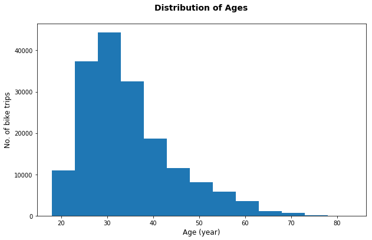

## Distribution of User Type

The system has two main type of users: *Subscriber* and *Customer*. The distribution shows that subscribers are the dorminant type of users of the bike hiring system recording over 90% of total trips. Customers seldomly use make use of the system recording barely 10% of total trips in February 2019.

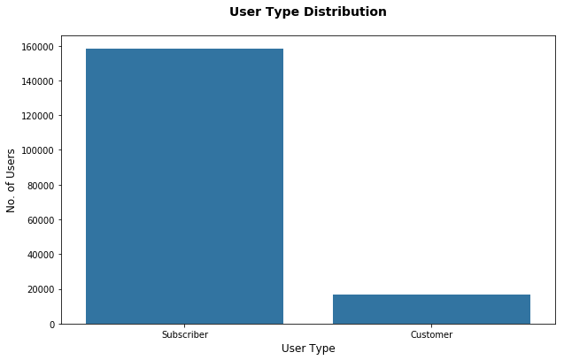

## Distribution of Start Time Weekdays

According to the distribution, Thursdays recorded the highest bike trips. Trips marginally decrease on Wednesdays relative to Thursdays. Tuesdays recorded marignal rise in bike trips than Wednesdays, whereas Mondays recorded lesser trips than Wednesdays and Fridays. Saturdays and Sundays recorded almost the same number of bike trips. The decrease order of bike trips in weekdays is: Thursday, Tuesday, Wednesday, Friday, Monday, Sunday, Saturday.

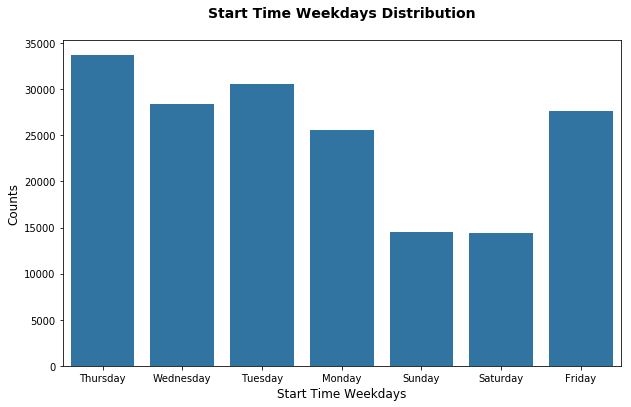

## Age vs. Duration by User Type

Generally, majority of users, regardless of their age, spend far less than 200 minutes per trip. It can be seen that the average age of subscribers is higher than that of customers and they spent shorter trip durations than customers.

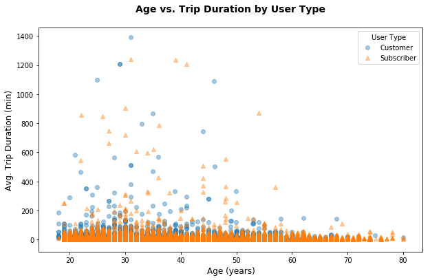

## Average Trip Duration vs. Weekday per User Type

The distribution shows that the average trip duration spent by customers per each start time weekday is higher than that spent by subcribers and probably so because subscribers are averagely older than customers.

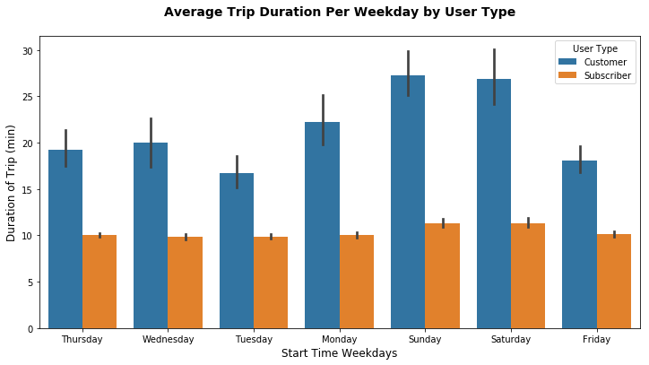